# Tidy Tuesday

Week 37

Author

Cristian T

Published

September 17, 2024

This week we are exploring Economic Diversity and Student Outcomes!

College students are back on campus in the US, so we’re exploring economic diversity and student outcomes! The dataset this week comes from Opportunity Insights via an article and associated interactive visualization from the Upshot at the New York Times.

“A new study, based on millions of anonymous tax records, shows that some colleges are even more economically segregated than previously understood, while others are associated with income mobility.”

This dataset offers an opportunity to explore the three rules that make a dataset “tidy”:

- Each variable is a column; each column is a variable.
- Each observation is a row; each row is an observation.
- Each value is a cell; each cell is a single value.

`college_admissions.csv

[output not shown]

# Load the data

```r
# Load the tidytuesday package
suppressMessages(library(tidytuesdayR)) # For accessing TidyTuesday datasets
suppressMessages(library(skimr)) # For summary and descriptive statistics
suppressMessages(library(tidyverse)) # For data manipulation and visualization
suppressMessages(library(dplyr)) # For data manipulation and transformation
suppressMessages(library(ggplot2)) # For data visualization
suppressMessages(library(RColorBrewer)) # For color palettes in visualizations
suppressMessages(library(ggimage) ) # For adding images to plots


# Load the current week's dataset
tuesdata <- tidytuesdayR::tt_load('2024-09-10')
# Extract datasets from the TidyTuesday dataset
college_admissions <- tuesdata$college_admissions

# Rename datasets
ca <- college_admissions


# Explore the structure of the dataset
str(ca) # Display the structure of 'college_admissions'
```

```
spc_tbl_ [1,946 × 80] (S3: spec_tbl_df/tbl_df/tbl/data.frame)
 $ super_opeid                    : num [1:1946] 1434 1434 1434 1434 1434 ...
 $ name                           : chr [1:1946] "American University" "American University" "American University" "American University" ...
 $ par_income_bin                 : num [1:1946] 10 30 50 65 75 85 92.5 95.5 96.5 97.5 ...
 $ par_income_lab                 : chr [1:1946] "0-20" "20-40" "40-60" "60-70" ...
 $ attend                         : num [1:1946] 0.00112 0.001 0.00141 0.00149 0.0015 ...
 $ stderr_attend                  : num [1:1946] 1.20e-04 9.41e-05 8.24e-05 9.20e-05 7.66e-05 ...
 $ attend_level                   : num [1:1946] 0.00161 0.00161 0.00161 0.00161 0.00161 ...
 $ attend_sat                     : num [1:1946] 0.00136 0.00206 0.00143 0.00141 0.00126 ...
 $ stderr_attend_sat              : num [1:1946] 0.000236 0.000167 0.00015 0.000165 0.000131 ...
 $ attend_level_sat               : num [1:1946] 0.00154 0.00154 0.00154 0.00154 0.00154 ...
 $ rel_apply                      : num [1:1946] 0.666 0.681 0.702 0.715 0.722 ...
 $ stderr_rel_apply               : num [1:1946] 0.0265 0.0209 0.0156 0.0174 0.0145 ...
 $ rel_attend                     : num [1:1946] 0.698 0.624 0.875 0.925 0.933 ...
 $ stderr_rel_attend              : num [1:1946] 0.0748 0.0585 0.0512 0.0572 0.0476 ...
 $ rel_att_cond_app               : num [1:1946] 1.047 0.917 1.246 1.293 1.292 ...
 $ rel_apply_sat                  : num [1:1946] 0.732 0.762 0.691 0.655 0.613 ...
 $ stderr_rel_apply_sat           : num [1:1946] 0.0527 0.0421 0.0291 0.0312 0.0254 ...
 $ rel_attend_sat                 : num [1:1946] 0.886 1.342 0.931 0.914 0.819 ...
 $ stderr_rel_attend_sat          : num [1:1946] 0.1538 0.1086 0.0978 0.1076 0.0849 ...
 $ rel_att_cond_app_sat           : num [1:1946] 1.21 1.76 1.35 1.4 1.34 ...
 $ attend_instate                 : num [1:1946] NA NA NA NA NA NA NA NA NA NA ...
 $ stderr_attend_instate          : num [1:1946] NA NA NA NA NA NA NA NA NA NA ...
 $ attend_level_instate           : num [1:1946] NA NA NA NA NA NA NA NA NA NA ...
 $ attend_instate_sat             : num [1:1946] NA NA NA NA NA NA NA NA NA NA ...
 $ stderr_attend_instate_sat      : num [1:1946] NA NA NA NA NA NA NA NA NA NA ...
 $ attend_level_instate_sat       : num [1:1946] NA NA NA NA NA NA NA NA NA NA ...
 $ attend_oostate                 : num [1:1946] NA NA NA NA NA NA NA NA NA NA ...
 $ stderr_attend_oostate          : num [1:1946] NA NA NA NA NA NA NA NA NA NA ...
 $ attend_level_oostate           : num [1:1946] NA NA NA NA NA NA NA NA NA NA ...
 $ attend_oostate_sat             : num [1:1946] NA NA NA NA NA NA NA NA NA NA ...
 $ stderr_attend_oostate_sat      : num [1:1946] NA NA NA NA NA NA NA NA NA NA ...
 $ attend_level_oostate_sat       : num [1:1946] NA NA NA NA NA NA NA NA NA NA ...
 $ rel_apply_instate              : num [1:1946] NA NA NA NA NA NA NA NA NA NA ...
 $ stderr_rel_apply_instate       : num [1:1946] NA NA NA NA NA NA NA NA NA NA ...
 $ rel_attend_instate             : num [1:1946] NA NA NA NA NA NA NA NA NA NA ...
 $ stderr_rel_attend_instate      : num [1:1946] NA NA NA NA NA NA NA NA NA NA ...
 $ rel_att_cond_app_instate       : num [1:1946] NA NA NA NA NA NA NA NA NA NA ...
 $ rel_apply_oostate              : num [1:1946] NA NA NA NA NA NA NA NA NA NA ...
 $ stderr_rel_apply_oostate       : num [1:1946] NA NA NA NA NA NA NA NA NA NA ...
```

[output cut: 110 more lines]

```
  ..   rel_attend_unwgt_oostate = col_double(),
  ..   stderr_rel_attend_unwgt_instate = col_double(),
  ..   stderr_rel_attend_unwgt_oostate = col_double(),
  ..   rel_apply_unwgt_instate = col_double(),
  ..   rel_apply_unwgt_oostate = col_double(),
  ..   stderr_rel_apply_unwgt_instate = col_double(),
  ..   stderr_rel_apply_unwgt_oostate = col_double(),
  ..   rel_att_cond_app_unwgt_instate = col_double(),
  ..   rel_att_cond_app_unwgt_oostate = col_double(),
  ..   public = col_logical(),
  ..   flagship = col_logical(),
  ..   tier = col_character(),
  ..   test_band_tier = col_character()
  .. )
 - attr(*, "problems")=<externalptr>
```

```r
skim(ca) # Provide detailed summary statistics for 'college_admissions' (missing values, summary stats)
```

Data summary

| Name | ca |
| --- | --- |
| Number of rows | 1946 |
| Number of columns | 80 |
| _______________________ |  |
| Column type frequency: |  |
| character | 4 |
| logical | 2 |
| numeric | 74 |
| ________________________ |  |
| Group variables | None |

**Variable type: character**

| skim_variable | n_missing | complete_rate | min | max | empty | n_unique | whitespace |
| --- | --- | --- | --- | --- | --- | --- | --- |
| name | 0 | 1 | 12 | 49 | 0 | 139 | 0 |
| par_income_lab | 0 | 1 | 4 | 7 | 0 | 14 | 0 |
| tier | 0 | 1 | 8 | 40 | 0 | 6 | 0 |
| test_band_tier | 0 | 1 | 6 | 21 | 0 | 6 | 0 |

**Variable type: logical**

| skim_variable | n_missing | complete_rate | mean | count |
| --- | --- | --- | --- | --- |
| public | 0 | 1 | 0.37 | FAL: 1232, TRU: 714 |
| flagship | 0 | 1 | 0.21 | FAL: 1540, TRU: 406 |

**Variable type: numeric**

| skim_variable | n_missing | complete_rate | mean | sd | p0 | p25 | p50 | p75 | p100 | hist |
| --- | --- | --- | --- | --- | --- | --- | --- | --- | --- | --- |
| super_opeid | 0 | 1.00 | 2528.51 | 1344.92 | 108.00 | 1536.00 | 2536.00 | 3223.00 | 11649.00 | ▇▇▁▁▁ |
| par_income_bin | 0 | 1.00 | 78.17 | 28.04 | 10.00 | 65.00 | 94.00 | 98.50 | 100.00 | ▁▁▁▂▇ |
| attend | 2 | 1.00 | 0.00 | 0.01 | 0.00 | 0.00 | 0.00 | 0.01 | 0.05 | ▇▁▁▁▁ |
| stderr_attend | 0 | 1.00 | 0.00 | 0.00 | 0.00 | 0.00 | 0.00 | 0.00 | 0.01 | ▇▁▁▁▁ |
| attend_level | 0 | 1.00 | 0.00 | 0.00 | 0.00 | 0.00 | 0.00 | 0.01 | 0.02 | ▇▂▁▁▁ |
| attend_sat | 294 | 0.85 | 0.00 | 0.00 | 0.00 | 0.00 | 0.00 | 0.01 | 0.04 | ▇▁▁▁▁ |
| stderr_attend_sat | 278 | 0.86 | 0.00 | 0.00 | 0.00 | 0.00 | 0.00 | 0.00 | 0.00 | ▇▁▁▁▁ |
| attend_level_sat | 0 | 1.00 | 0.00 | 0.00 | 0.00 | 0.00 | 0.00 | 0.00 | 0.02 | ▇▂▁▁▁ |
| rel_apply | 0 | 1.00 | 1.17 | 0.56 | 0.07 | 0.83 | 1.05 | 1.34 | 5.87 | ▇▃▁▁▁ |
| stderr_rel_apply | 0 | 1.00 | 0.04 | 0.04 | 0.01 | 0.02 | 0.03 | 0.05 | 0.53 | ▇▁▁▁▁ |
| rel_attend | 2 | 1.00 | 1.27 | 0.93 | 0.01 | 0.76 | 1.03 | 1.45 | 10.26 | ▇▁▁▁▁ |
| stderr_rel_attend | 0 | 1.00 | 0.11 | 0.12 | 0.00 | 0.05 | 0.08 | 0.13 | 1.57 | ▇▁▁▁▁ |
| rel_att_cond_app | 2 | 1.00 | 1.03 | 0.27 | 0.05 | 0.88 | 1.00 | 1.15 | 3.06 | ▁▇▂▁▁ |
| rel_apply_sat | 278 | 0.86 | 1.15 | 0.51 | 0.19 | 0.79 | 1.06 | 1.36 | 4.70 | ▇▆▁▁▁ |
| stderr_rel_apply_sat | 278 | 0.86 | 0.07 | 0.05 | 0.02 | 0.03 | 0.06 | 0.09 | 0.56 | ▇▁▁▁▁ |
| rel_attend_sat | 294 | 0.85 | 1.19 | 0.75 | 0.02 | 0.71 | 0.99 | 1.48 | 8.03 | ▇▂▁▁▁ |
| stderr_rel_attend_sat | 278 | 0.86 | 0.18 | 0.13 | 0.00 | 0.08 | 0.15 | 0.24 | 0.95 | ▇▃▁▁▁ |
| rel_att_cond_app_sat | 294 | 0.85 | 1.01 | 0.35 | 0.04 | 0.82 | 0.98 | 1.17 | 3.85 | ▂▇▁▁▁ |
| attend_instate | 1334 | 0.31 | 0.13 | 0.08 | 0.00 | 0.06 | 0.13 | 0.18 | 0.41 | ▇▇▅▂▁ |
| stderr_attend_instate | 1334 | 0.31 | 0.01 | 0.01 | 0.00 | 0.00 | 0.01 | 0.01 | 0.08 | ▇▁▁▁▁ |
| attend_level_instate | 1232 | 0.37 | 0.12 | 0.07 | 0.02 | 0.05 | 0.13 | 0.17 | 0.36 | ▇▇▆▂▁ |
| attend_instate_sat | 1334 | 0.31 | 0.13 | 0.10 | 0.00 | 0.04 | 0.11 | 0.18 | 0.66 | ▇▃▂▁▁ |
| stderr_attend_instate_sat | 1334 | 0.31 | 0.02 | 0.02 | 0.00 | 0.00 | 0.01 | 0.02 | 0.15 | ▇▁▁▁▁ |
| attend_level_instate_sat | 1232 | 0.37 | 0.12 | 0.08 | 0.01 | 0.03 | 0.11 | 0.16 | 0.39 | ▇▇▃▁▁ |
| attend_oostate | 1336 | 0.31 | 0.00 | 0.00 | 0.00 | 0.00 | 0.00 | 0.00 | 0.02 | ▇▁▁▁▁ |
| stderr_attend_oostate | 1334 | 0.31 | 0.00 | 0.00 | 0.00 | 0.00 | 0.00 | 0.00 | 0.00 | ▇▂▁▁▁ |
| attend_level_oostate | 1232 | 0.37 | 0.00 | 0.00 | 0.00 | 0.00 | 0.00 | 0.00 | 0.00 | ▇▆▂▁▁ |
| attend_oostate_sat | 1346 | 0.31 | 0.00 | 0.00 | 0.00 | 0.00 | 0.00 | 0.00 | 0.01 | ▇▁▁▁▁ |
| stderr_attend_oostate_sat | 1334 | 0.31 | 0.00 | 0.00 | 0.00 | 0.00 | 0.00 | 0.00 | 0.00 | ▇▂▂▁▁ |
| attend_level_oostate_sat | 1232 | 0.37 | 0.00 | 0.00 | 0.00 | 0.00 | 0.00 | 0.00 | 0.00 | ▇▆▃▂▂ |
| rel_apply_instate | 1334 | 0.31 | 1.01 | 0.17 | 0.27 | 0.91 | 1.00 | 1.12 | 1.70 | ▁▁▇▃▁ |
| stderr_rel_apply_instate | 1334 | 0.31 | 0.03 | 0.02 | 0.01 | 0.01 | 0.02 | 0.03 | 0.13 | ▇▂▁▁▁ |
| rel_attend_instate | 1334 | 0.31 | 1.03 | 0.30 | 0.14 | 0.86 | 1.01 | 1.20 | 2.19 | ▁▆▇▂▁ |
| stderr_rel_attend_instate | 1334 | 0.31 | 0.06 | 0.04 | 0.01 | 0.03 | 0.05 | 0.07 | 0.31 | ▇▂▁▁▁ |
| rel_att_cond_app_instate | 1334 | 0.31 | 1.01 | 0.19 | 0.37 | 0.90 | 1.00 | 1.11 | 1.70 | ▁▃▇▂▁ |
| rel_apply_oostate | 1334 | 0.31 | 1.19 | 0.55 | 0.32 | 0.75 | 1.10 | 1.54 | 4.14 | ▇▆▂▁▁ |
| stderr_rel_apply_oostate | 1334 | 0.31 | 0.05 | 0.04 | 0.01 | 0.02 | 0.03 | 0.06 | 0.26 | ▇▂▁▁▁ |
| rel_attend_oostate | 1336 | 0.31 | 1.30 | 0.87 | 0.24 | 0.63 | 1.08 | 1.74 | 5.86 | ▇▃▁▁▁ |
| stderr_rel_attend_oostate | 1334 | 0.31 | 0.14 | 0.11 | 0.00 | 0.06 | 0.11 | 0.18 | 0.75 | ▇▃▁▁▁ |
| rel_att_cond_app_oostate | 1336 | 0.31 | 1.02 | 0.28 | 0.34 | 0.82 | 1.01 | 1.18 | 2.42 | ▂▇▃▁▁ |
| rel_apply_instate_sat | 1334 | 0.31 | 1.02 | 0.20 | 0.31 | 0.90 | 1.00 | 1.16 | 1.57 | ▁▂▇▅▁ |
| stderr_rel_apply_instate_sat | 1334 | 0.31 | 0.06 | 0.04 | 0.02 | 0.03 | 0.05 | 0.07 | 0.28 | ▇▂▁▁▁ |
| rel_attend_instate_sat | 1334 | 0.31 | 1.07 | 0.44 | 0.09 | 0.79 | 1.00 | 1.27 | 2.95 | ▂▇▃▁▁ |
| stderr_rel_attend_instate_sat | 1334 | 0.31 | 0.14 | 0.10 | 0.03 | 0.07 | 0.11 | 0.16 | 0.71 | ▇▂▁▁▁ |
| rel_att_cond_app_instate_sat | 1334 | 0.31 | 1.03 | 0.30 | 0.15 | 0.86 | 1.00 | 1.15 | 2.17 | ▁▆▇▁▁ |
| rel_apply_oostate_sat | 1334 | 0.31 | 1.30 | 0.70 | 0.28 | 0.73 | 1.12 | 1.73 | 4.21 | ▇▅▃▁▁ |
| stderr_rel_apply_oostate_sat | 1334 | 0.31 | 0.11 | 0.09 | 0.02 | 0.04 | 0.08 | 0.15 | 0.67 | ▇▂▁▁▁ |
| rel_attend_oostate_sat | 1346 | 0.31 | 1.49 | 1.21 | 0.06 | 0.55 | 1.07 | 2.09 | 9.01 | ▇▃▁▁▁ |
| stderr_rel_attend_oostate_sat | 1334 | 0.31 | 0.34 | 0.31 | 0.00 | 0.11 | 0.24 | 0.47 | 2.14 | ▇▃▁▁▁ |
| rel_att_cond_app_oostate_sat | 1346 | 0.31 | 1.05 | 0.42 | 0.10 | 0.76 | 0.99 | 1.25 | 2.59 | ▂▇▅▁▁ |
| attend_unwgt | 1 | 1.00 | 0.00 | 0.00 | 0.00 | 0.00 | 0.00 | 0.00 | 0.02 | ▇▁▁▁▁ |
| stderr_attend_unwgt | 0 | 1.00 | 0.00 | 0.00 | 0.00 | 0.00 | 0.00 | 0.00 | 0.00 | ▇▁▁▁▁ |
| attend_unwgt_level | 0 | 1.00 | 0.00 | 0.00 | 0.00 | 0.00 | 0.00 | 0.00 | 0.00 | ▇▂▂▁▁ |
| attend_unwgt_instate | 1334 | 0.31 | 0.09 | 0.08 | 0.00 | 0.03 | 0.07 | 0.14 | 0.35 | ▇▃▂▁▁ |
| stderr_attend_unwgt_instate | 1334 | 0.31 | 0.01 | 0.01 | 0.00 | 0.00 | 0.00 | 0.01 | 0.04 | ▇▁▁▁▁ |
| attend_unwgt_oostate | 1337 | 0.31 | 0.00 | 0.00 | 0.00 | 0.00 | 0.00 | 0.00 | 0.01 | ▇▁▁▁▁ |
| stderr_attend_unwgt_oostate | 1334 | 0.31 | 0.00 | 0.00 | 0.00 | 0.00 | 0.00 | 0.00 | 0.00 | ▇▂▁▁▁ |
| attend_unwgt_level_instate | 1232 | 0.37 | 0.07 | 0.05 | 0.01 | 0.02 | 0.07 | 0.10 | 0.24 | ▇▆▂▂▁ |
| attend_unwgt_level_oostate | 1232 | 0.37 | 0.00 | 0.00 | 0.00 | 0.00 | 0.00 | 0.00 | 0.00 | ▇▅▃▁▁ |
| rel_attend_unwgt | 1 | 1.00 | 2.48 | 3.10 | 0.00 | 0.62 | 1.41 | 2.94 | 30.80 | ▇▁▁▁▁ |
| rel_apply_unwgt | 0 | 1.00 | 1.98 | 1.77 | 0.09 | 0.71 | 1.42 | 2.62 | 13.77 | ▇▂▁▁▁ |
| stderr_rel_attend_unwgt | 0 | 1.00 | 0.20 | 0.35 | 0.00 | 0.03 | 0.07 | 0.22 | 3.21 | ▇▁▁▁▁ |
| stderr_rel_apply_unwgt | 0 | 1.00 | 0.06 | 0.09 | 0.00 | 0.01 | 0.03 | 0.07 | 1.06 | ▇▁▁▁▁ |
| rel_att_cond_app_unwgt | 1 | 1.00 | 1.06 | 0.39 | 0.01 | 0.84 | 1.00 | 1.20 | 4.95 | ▇▇▁▁▁ |
| rel_attend_unwgt_instate | 1334 | 0.31 | 1.30 | 0.73 | 0.18 | 0.79 | 1.10 | 1.64 | 4.70 | ▇▆▂▁▁ |
| rel_attend_unwgt_oostate | 1337 | 0.31 | 1.82 | 1.67 | 0.09 | 0.53 | 1.29 | 2.82 | 12.10 | ▇▃▁▁▁ |
| stderr_rel_attend_unwgt_instate | 1334 | 0.31 | 0.07 | 0.05 | 0.01 | 0.03 | 0.05 | 0.09 | 0.34 | ▇▂▁▁▁ |
| stderr_rel_attend_unwgt_oostate | 1334 | 0.31 | 0.16 | 0.15 | 0.00 | 0.04 | 0.10 | 0.24 | 0.93 | ▇▃▁▁▁ |
| rel_apply_unwgt_instate | 1334 | 0.31 | 1.19 | 0.43 | 0.35 | 0.86 | 1.10 | 1.49 | 2.40 | ▃▇▅▃▁ |
| rel_apply_unwgt_oostate | 1334 | 0.31 | 1.57 | 1.08 | 0.17 | 0.69 | 1.31 | 2.26 | 7.07 | ▇▅▁▁▁ |
| stderr_rel_apply_unwgt_instate | 1334 | 0.31 | 0.03 | 0.02 | 0.00 | 0.01 | 0.02 | 0.04 | 0.12 | ▇▃▁▁▁ |
| stderr_rel_apply_unwgt_oostate | 1334 | 0.31 | 0.05 | 0.04 | 0.00 | 0.01 | 0.03 | 0.07 | 0.31 | ▇▃▁▁▁ |
| rel_att_cond_app_unwgt_instate | 1334 | 0.31 | 1.04 | 0.27 | 0.40 | 0.86 | 1.01 | 1.17 | 2.09 | ▂▇▅▁▁ |
| rel_att_cond_app_unwgt_oostate | 1337 | 0.31 | 1.02 | 0.33 | 0.19 | 0.78 | 1.00 | 1.21 | 2.14 | ▂▇▇▂▁ |

```r
# Export data
#write.csv(college_admissions, "college_admissions.csv", row.names = FALSE)



#tidytuesdayR::use_tidytemplate()
```

```r
#### Clean the data

# 42 columns have a significant number of missing values (over 1300).
```

#### EDA

```r
# Summarize college_admissions
summary(college_admissions)
```

```
  super_opeid        name           par_income_bin   par_income_lab
 Min.   :  108   Length:1946        Min.   : 10.00   Length:1946
 1st Qu.: 1536   Class :character   1st Qu.: 65.00   Class :character
 Median : 2536   Mode  :character   Median : 94.00   Mode  :character
 Mean   : 2529                      Mean   : 78.17
 3rd Qu.: 3223                      3rd Qu.: 98.50
 Max.   :11649                      Max.   :100.00

     attend          stderr_attend        attend_level         attend_sat
 Min.   :0.0000289   Min.   :0.0000000   Min.   :0.0004208   Min.   :0.00002
 1st Qu.:0.0014042   1st Qu.:0.0001146   1st Qu.:0.0013405   1st Qu.:0.00108
 Median :0.0030317   Median :0.0002052   Median :0.0025648   Median :0.00236
 Mean   :0.0048257   Mean   :0.0003537   Mean   :0.0040984   Mean   :0.00401
 3rd Qu.:0.0065213   3rd Qu.:0.0003800   3rd Qu.:0.0058981   3rd Qu.:0.00532
 Max.   :0.0460693   Max.   :0.0054024   Max.   :0.0201221   Max.   :0.04233
 NA's   :2                                                   NA's   :294
 stderr_attend_sat attend_level_sat      rel_apply       stderr_rel_apply
 Min.   :0.00000   Min.   :0.0003987   Min.   :0.07044   Min.   :0.007235
 1st Qu.:0.00017   1st Qu.:0.0010742   1st Qu.:0.83192   1st Qu.:0.018424
 Median :0.00031   Median :0.0021369   Median :1.04823   Median :0.027626
 Mean   :0.00048   Mean   :0.0035109   Mean   :1.17263   Mean   :0.039336
 3rd Qu.:0.00060   3rd Qu.:0.0042152   3rd Qu.:1.33672   3rd Qu.:0.047375
 Max.   :0.00375   Max.   :0.0188583   Max.   :5.87360   Max.   :0.529336
 NA's   :278
   rel_attend       stderr_rel_attend rel_att_cond_app  rel_apply_sat
 Min.   : 0.01001   Min.   :0.00000   Min.   :0.05321   Min.   :0.1882
 1st Qu.: 0.75943   1st Qu.:0.04634   1st Qu.:0.87686   1st Qu.:0.7904
 Median : 1.02585   Median :0.07896   Median :1.00280   Median :1.0561
 Mean   : 1.27325   Mean   :0.11122   Mean   :1.02935   Mean   :1.1462
 3rd Qu.: 1.44678   3rd Qu.:0.13243   3rd Qu.:1.14920   3rd Qu.:1.3623
 Max.   :10.26102   Max.   :1.57053   Max.   :3.05958   Max.   :4.7022
 NA's   :2                            NA's   :2         NA's   :278
 stderr_rel_apply_sat rel_attend_sat    stderr_rel_attend_sat
 Min.   :0.01530      Min.   :0.01877   Min.   :0.00000
 1st Qu.:0.03348      1st Qu.:0.70931   1st Qu.:0.08469
 Median :0.05573      Median :0.98758   Median :0.14685
 Mean   :0.06879      Mean   :1.19216   Mean   :0.18422
 3rd Qu.:0.09026      3rd Qu.:1.47978   3rd Qu.:0.23587
 Max.   :0.56117      Max.   :8.03421   Max.   :0.95318
 NA's   :278          NA's   :294       NA's   :278
```

[output cut: 157 more lines]

```
 3rd Qu.:0.0711                 3rd Qu.:1.1704
 Max.   :0.3051                 Max.   :2.0890
 NA's   :1334                   NA's   :1334
 rel_att_cond_app_unwgt_oostate   public         flagship
 Min.   :0.1896                 Mode :logical   Mode :logical
 1st Qu.:0.7835                 FALSE:1232      FALSE:1540
 Median :0.9986                 TRUE :714       TRUE :406
 Mean   :1.0161
 3rd Qu.:1.2054
 Max.   :2.1428
 NA's   :1337
     tier           test_band_tier
 Length:1946        Length:1946
 Class :character   Class :character
 Mode  :character   Mode  :character
```

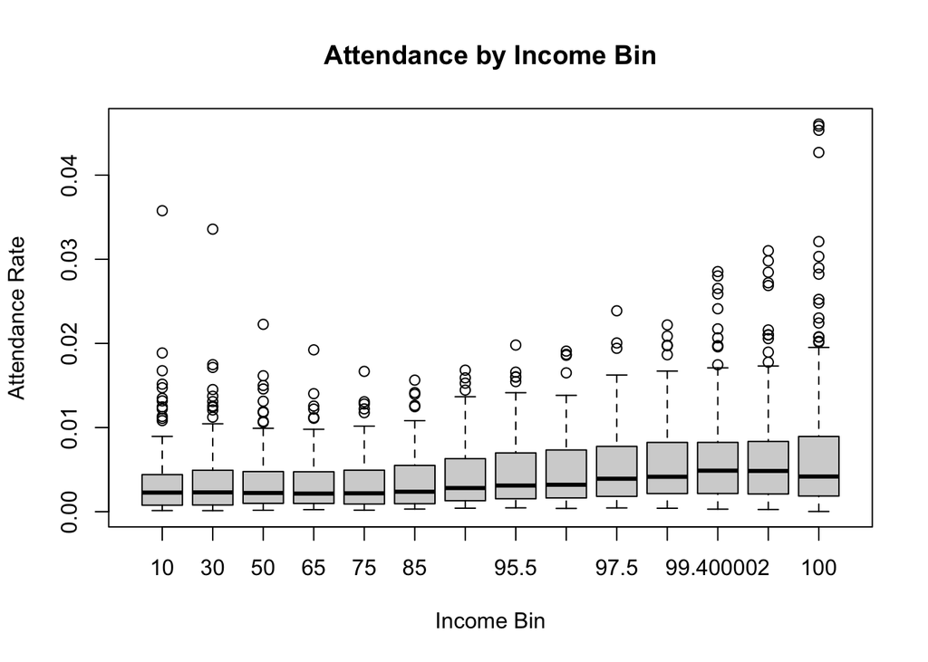

```r
# Create a boxplot parent income vs attendance
boxplot(attend ~ par_income_bin, data=ca, main="Attendance by Income Bin", xlab="Income Bin", ylab="Attendance Rate")
```

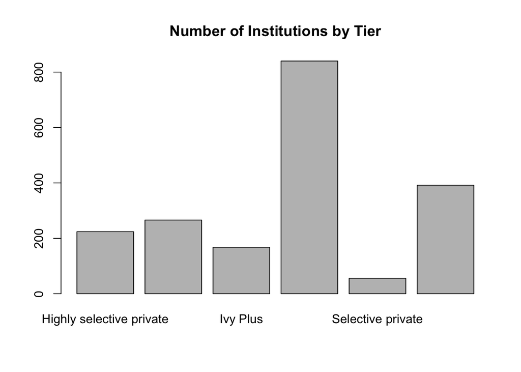

```r
# Create a bar plot institutions by their tier
barplot(table(ca$tier), main="Number of Institutions by Tier")
```

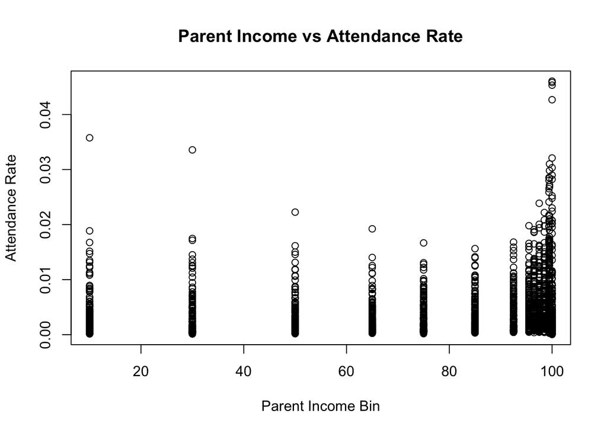

```r
# Create a scatterplot parent income v attendance
plot(ca$par_income_bin, ca$attend, main="Parent Income vs Attendance Rate", xlab="Parent Income Bin", ylab="Attendance Rate")
```

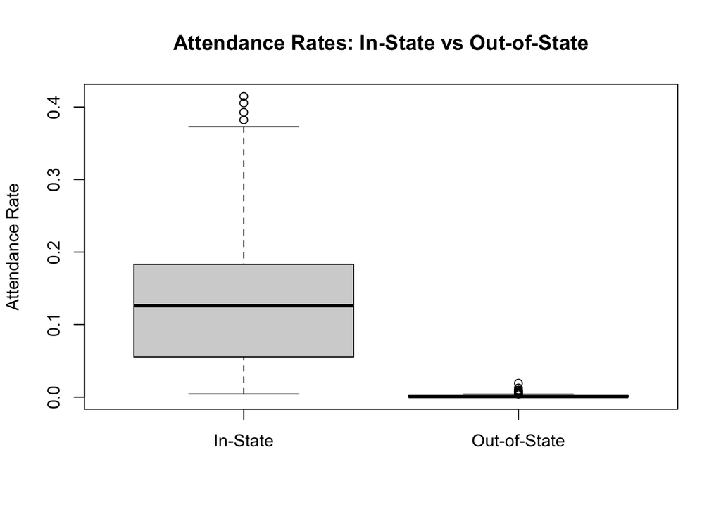

```r
# Create a boxplot in-state vs out-of-state attendance
boxplot(ca$attend_instate, ca$attend_oostate, names=c("In-State", "Out-of-State"), main="Attendance Rates: In-State vs Out-of-State", ylab="Attendance Rate")
```

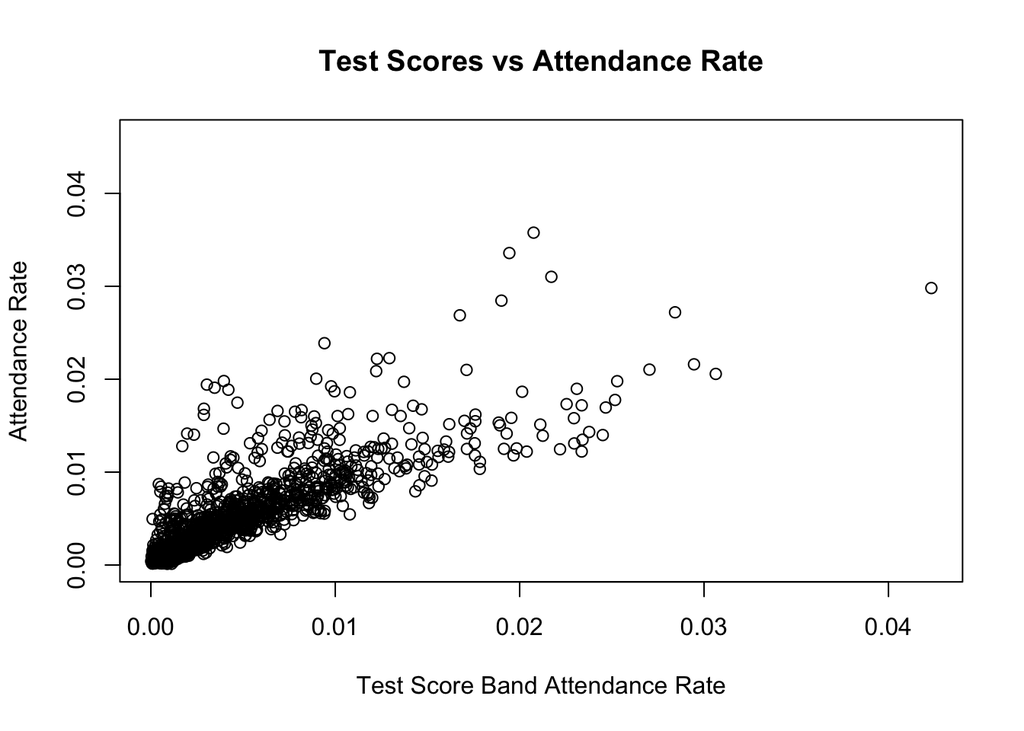

```r
# Create a scatterplot SAT attendance vs overall attendance rates
plot(ca$attend_sat, ca$attend, main="Test Scores vs Attendance Rate", xlab="Test Score Band Attendance Rate", ylab="Attendance Rate")
```

```r
# Filter higher-income
attend_by_income_bin <- ca %>%
  filter(par_income_bin > 80) %>%
  select(name, par_income_bin, attend, tier) %>% # par_income_lab
  group_by(par_income_bin)
attend_by_income_bin
```

| name | par_income_bin | attend | tier |
| --- | --- | --- | --- |
| American University | 85.0 | 1.524228e-03 | Highly selective private |
| American University | 92.5 | 1.695167e-03 | Highly selective private |
| American University | 95.5 | 2.261346e-03 | Highly selective private |
| American University | 96.5 | 2.109482e-03 | Highly selective private |
| American University | 97.5 | 2.267590e-03 | Highly selective private |
| American University | 98.5 | 2.484247e-03 | Highly selective private |
| American University | 99.4 | 3.078112e-03 | Highly selective private |
| American University | 99.5 | 3.030860e-03 | Highly selective private |
| American University | 100.0 | 2.873795e-03 | Highly selective private |
| Amherst College | 85.0 | 1.348111e-03 | Other elite schools (public and private) |

[output cut: 1241 more lines]

```r
# Summarize higher-income by mean, median, and standard deviation
summary_stats <- ca %>%
  group_by(par_income_bin) %>%
  summarize(
    mean_attend = mean(attend, na.rm = TRUE),
    median_attend = median(attend, na.rm = TRUE),
    sd_attend = sd(attend, na.rm = TRUE)
  )
summary_stats
```

| par_income_bin | mean_attend | median_attend | sd_attend |
| --- | --- | --- | --- |
| 10.0 | 0.003665678 | 0.002270875 | 0.004638523 |
| 30.0 | 0.003656823 | 0.002295467 | 0.004411924 |
| 50.0 | 0.003504727 | 0.002226353 | 0.003659813 |
| 65.0 | 0.003337591 | 0.002154475 | 0.003210391 |
| 75.0 | 0.003412416 | 0.002186013 | 0.003180826 |
| 85.0 | 0.003668668 | 0.002373076 | 0.003354503 |
| 92.5 | 0.004183249 | 0.002813860 | 0.003673880 |
| 95.5 | 0.004668307 | 0.003105551 | 0.004072769 |
| 96.5 | 0.004953355 | 0.003199434 | 0.004236486 |
| 97.5 | 0.005434125 | 0.003918635 | 0.004658010 |

[output cut: 4 more lines]

```r
#  As income increases, both the mean and median attendance rates rise, suggesting that students from wealthier households are more likely to attend college. The standard deviation decreases slightly for middle-income groups and then increases again for higher-income bins. The standard deviation for low and middle-income bins (10 to 85) is relatively low and stable, suggesting that attendance rates in these income groups are relatively similar and clustered around the mean.

# Filter data for lower income bins (e.g., income <= 50)
# low_income_data <- ca %>%
#   filter(par_income_bin <= 30)

# Group by school and calculate number of students from lower-income bins attending each school
# schools_for_poor_kids <- low_income_data %>%
#   group_by(name) %>%
#   summarise(weighted_attendance_rate = sum(attend, na.rm = TRUE)) %>%
#   arrange(desc(weighted_attendance_rate))
# schools_for_poor_kids

# Filter data for upper income bins (e.g., income >= 92.5)
# rich_income_data <- ca %>%
#   filter(par_income_bin <= 99.5)

# Group by school and calculate number of students from lower-income bins attending each school
# schools_for_rich_kids <- rich_income_data %>%
#   group_by(name) %>%
#   summarise(weighted_attendance_rate = sum(attend, na.rm = TRUE)) %>%
#   arrange(desc(weighted_attendance_rate))
# schools_for_rich_kids


# unique(ca$name)

# ND_attend_by_income_bin <- ca %>%
#   filter(name == "University Of Notre Dame") %>%
#   select(par_income_bin, attend, tier) %>%
#   group_by(par_income_bin)

# attend_by_income_bin <- ca %>%
#   filter(name == "American University") %>%
#   select(par_income_bin, attend, tier) %>%
#   group_by(par_income_bin)

# NM_attend_by_income_bin <- ca %>%
  # filter(name == "University Of New Mexico") %>%
  # select(par_income_bin, attend, tier) %>%
  # group_by(par_income_bin)
# NM_attend_by_income_bin
```

#### Plot 1 Comparison of Attendance Rates by Income Group

```r
# Filter data for lower income bins income <= 30
low_income_data <- ca %>%
  filter(par_income_bin <= 30)

# Group by school and calculate number of students from lower-income bins attending each school
schools_for_poor_kids <- low_income_data %>%
  group_by(name) %>% # Group data by school name
  summarise(weighted_attendance_rate = sum(attend, na.rm = TRUE)) %>% # Summarize attendance by summing up the number of students
  arrange(desc(weighted_attendance_rate)) # Arrange schools in descending order of attendance rate
schools_for_poor_kids
```

| name | weighted_attendance_rate |
| --- | --- |
| Harvard University | 0.0693534540 |
| University Of California, Berkeley | 0.0363465560 |
| Yale University | 0.0318743840 |
| Massachusetts Institute Of Technology | 0.0304809530 |
| Princeton University | 0.0279905330 |
| Stanford University | 0.0275842830 |
| Cornell University | 0.0253061320 |
| University Of California, Los Angeles | 0.0252599770 |
| New York University | 0.0250147670 |
| Columbia University In The City Of New York | 0.0220669960 |

[output cut: 129 more lines]

```r
# Filter data for upper income bins income >= 92.5
super_rich_income_data <- ca %>%
  filter(par_income_bin <= 99.5)

# Group by school and calculate number of students from lower-income bins attending each school
schools_for_super_rich_kids <- super_rich_income_data %>%
  group_by(name) %>% # Group data by school name
  summarise(weighted_attendance_rate = sum(attend, na.rm = TRUE)) %>% # Summarize attendance by summing up the number of students
  arrange(desc(weighted_attendance_rate)) # Arrange schools in descending order of attendance rate
schools_for_super_rich_kids
```

| name | weighted_attendance_rate |
| --- | --- |
| Harvard University | 0.297538159 |
| Yale University | 0.213610616 |
| University Of California, Berkeley | 0.207025781 |
| Princeton University | 0.196977735 |
| University Of Michigan - Ann Arbor | 0.194389814 |
| Stanford University | 0.190309333 |
| Massachusetts Institute Of Technology | 0.186263200 |
| University Of Pennsylvania | 0.182672086 |
| Cornell University | 0.166362295 |
| University Of Chicago | 0.149116389 |

[output cut: 129 more lines]

```r
# Combine the two datasets: schools_for_poor_kids and schools_for_super_rich_kids
attendance_combined <- schools_for_poor_kids %>%
  rename(lower_income_attendance = weighted_attendance_rate) %>%  # Rename column for clarity
  left_join(schools_for_super_rich_kids %>%
              rename(upper_income_attendance = weighted_attendance_rate), # Rename column
            by = "name") # Merge data frames by school name

# Calculate the gap between upper and lower-income attendance rates
attendance_combined <- attendance_combined %>%
  mutate(gap = upper_income_attendance - lower_income_attendance) # Calculate the gap between upper and lower-income attendance

# Sort by the largest gap
attendance_combined <- attendance_combined %>%
  arrange(desc(gap)) # Arrange schools in descending order of the gap
attendance_combined
```

| name | lower_income_attendance | upper_income_attendance | gap |
| --- | --- | --- | --- |
| Harvard University | 0.0693534540 | 0.297538159 | 0.228184705 |
| Yale University | 0.0318743840 | 0.213610616 | 0.181736232 |
| University Of Michigan - Ann Arbor | 0.0167231001 | 0.194389814 | 0.177666714 |
| University Of California, Berkeley | 0.0363465560 | 0.207025781 | 0.170679225 |
| Princeton University | 0.0279905330 | 0.196977735 | 0.168987202 |
| University Of Pennsylvania | 0.0156740844 | 0.182672086 | 0.166998001 |
| Stanford University | 0.0275842830 | 0.190309333 | 0.162725050 |
| Massachusetts Institute Of Technology | 0.0304809530 | 0.186263200 | 0.155782247 |
| Cornell University | 0.0253061320 | 0.166362295 | 0.141056163 |
| University Of Chicago | 0.0205394793 | 0.149116389 | 0.128576909 |

[output cut: 129 more lines]

[figure not shown]

```r
# Filter the top 15 universities by gap
attendance_combined_top <- attendance_combined %>%
  top_n(15, wt = gap) %>% # Select the top 15 schools with the largest gaps
  mutate(lower_income_attendance_percent = lower_income_attendance * 100,
         upper_income_attendance_percent = upper_income_attendance * 100) %>%
  arrange(desc(gap)) # Arrange by gap

# Get images for graph by creating a dataframe with university names and logo URLs
logos <- data.frame(
  name = c("Harvard University", "Yale University", "University Of Michigan - Ann Arbor",
           "University Of California, Berkeley", "Princeton University", "University Of Pennsylvania",
           "Stanford University", "Massachusetts Institute Of Technology",
           "Cornell University", "University Of Chicago", "Northwestern University",
           "Columbia University In The City Of New York", "University Of Texas At Austin",
           "Washington University In St. Louis", "University Of Notre Dame"),
  logo_url2 = c("/Users/cristianthirteen/Downloads/Notre Dame/Tidy Tuesday/2024-09-10 Economic Diversity and Student Outcomes/Harvard_University.png",
               "/Users/cristianthirteen/Downloads/Notre Dame/Tidy Tuesday/2024-09-10 Economic Diversity and Student Outcomes/Yale_University.png",
               "/Users/cristianthirteen/Downloads/Notre Dame/Tidy Tuesday/2024-09-10 Economic Diversity and Student Outcomes/University_of_Michigan.png",
               "/Users/cristianthirteen/Downloads/Notre Dame/Tidy Tuesday/2024-09-10 Economic Diversity and Student Outcomes/University_of_California,_Berkeley.png",
               "/Users/cristianthirteen/Downloads/Notre Dame/Tidy Tuesday/2024-09-10 Economic Diversity and Student Outcomes/Princeton_logo.png",
               "/Users/cristianthirteen/Downloads/Notre Dame/Tidy Tuesday/2024-09-10 Economic Diversity and Student Outcomes/University_of_Pennsylvania.png",
               "/Users/cristianthirteen/Downloads/Notre Dame/Tidy Tuesday/2024-09-10 Economic Diversity and Student Outcomes/Stanford_logo.png",
               "/Users/cristianthirteen/Downloads/Notre Dame/Tidy Tuesday/2024-09-10 Economic Diversity and Student Outcomes/MIT.png",
               "/Users/cristianthirteen/Downloads/Notre Dame/Tidy Tuesday/2024-09-10 Economic Diversity and Student Outcomes/Cornell_University.png",
               "/Users/cristianthirteen/Downloads/Notre Dame/Tidy Tuesday/2024-09-10 Economic Diversity and Student Outcomes/University_of_Chicago.png",
               "/Users/cristianthirteen/Downloads/Notre Dame/Tidy Tuesday/2024-09-10 Economic Diversity and Student Outcomes/Northwestern_University.png",
               "/Users/cristianthirteen/Downloads/Notre Dame/Tidy Tuesday/2024-09-10 Economic Diversity and Student Outcomes/Columbia_University.png",
               "/Users/cristianthirteen/Downloads/Notre Dame/Tidy Tuesday/2024-09-10 Economic Diversity and Student Outcomes/University_of_Texas.png",
               "/Users/cristianthirteen/Downloads/Notre Dame/Tidy Tuesday/2024-09-10 Economic Diversity and Student Outcomes/Washington_University_in_St._Louis.png",
               "/Users/cristianthirteen/Downloads/Notre Dame/Tidy Tuesday/2024-09-10 Economic Diversity and Student Outcomes/University_of_Notre_Dame.png")
)

# Combine the attendance data with the logos
attendance_combined_top <- attendance_combined_top %>%
  left_join(logos, by = "name") # Join the logos dataframe with the attendance data

# Create a Dumbbell Chart for the top 15 universities
ggplot(attendance_combined_top, aes(x = lower_income_attendance_percent,
                                    xend = upper_income_attendance_percent,
                                    y = reorder(name, gap))) +
  geom_segment(aes(x = lower_income_attendance_percent, xend = upper_income_attendance_percent,
                   y = reorder(name, gap), yend = reorder(name, gap)),
               color = "gray", size = 1.0) + # Line connecting the points
  geom_point(aes(x = lower_income_attendance_percent),
             color = brewer.pal(3, "Set2")[1], size = 4) + # Lower-income point
  geom_point(aes(x = upper_income_attendance_percent),
             color = brewer.pal(3, "Set2")[2], size = 4) + # Upper-income point
  geom_text(aes(x = lower_income_attendance_percent,
                label = paste0(round(lower_income_attendance_percent, 1), "%")), hjust = 1.5, size = 3.5) + # Lower-income label
  geom_text(aes(x = upper_income_attendance_percent, label = paste0(round(upper_income_attendance_percent, 1), "%")), hjust = -0.2, size = 3.5) + # Upper-income label
  geom_text(aes(label = paste0(round(gap * 100, 1), "%"), x = (lower_income_attendance_percent + upper_income_attendance_percent) / 2), color = "black", vjust = -1.5, size = 3.5) + # Adding the gap label, rounded to 2 decimals
  geom_image(aes(x = -1.5, y = reorder(name, gap), image = logo_url2), size = 0.13, by = "width") + # Adding logos
  labs(title = "Comparison of Attendance Rates by Income Group",
       subtitle = "Lower-Income vs. Upper-Income Students",
       x = "Attendance Rate (%)",
       y = NULL) + # Remove the y-axis title
  theme_minimal() +
  theme(axis.text.x = element_blank(), # Remove x-axis text
        axis.text.y = element_blank(), # Remove y-axis text
        axis.title.x = element_blank(),
        plot.title = element_text(size = 14, face = "bold"),
        panel.grid.major = element_blank(),
        panel.grid.minor = element_blank())
```

#### Plot 2 Mean Attendance Gap by Institution Tier

Compare the attendance gaps with similar institutions to understand whether certain universities are outliers or if similar patterns exist across peers.

```r
# Merge CA dataset with attendance_combined on 'name'
merged_ca <- merge(attendance_combined, ca, by = "name", all.x = TRUE)

# Filter schools from previous plot
my_15 <- merged_ca %>%
  filter(name %in% c("Harvard University", "Yale University", "University Of Michigan - Ann Arbor", "University Of California, Berkeley", "Princeton University", "University Of Pennsylvania", "Stanford University", "Massachusetts Institute Of Technology", "Cornell University", "University Of Chicago", "Northwestern University", "Columbia University In The City Of New York", "University Of Texas At Austin", "Washington University In St. Louis", "University Of Notre Dame")) %>%
  select(name, tier, lower_income_attendance, upper_income_attendance, gap)
unique(my_15)
```

|  | name | tier | lower_income_attendance | upper_income_attendance | gap |
| --- | --- | --- | --- | --- | --- |
| 1 | Columbia University In The City Of New York | Ivy Plus | 0.022066996 | 0.1406238 | 0.1185568 |
| 15 | Cornell University | Ivy Plus | 0.025306132 | 0.1663623 | 0.1410562 |
| 29 | Harvard University | Ivy Plus | 0.069353454 | 0.2975382 | 0.2281847 |
| 43 | Massachusetts Institute Of Technology | Ivy Plus | 0.030480953 | 0.1862632 | 0.1557822 |
| 57 | Northwestern University | Other elite schools (public and private) | 0.015455484 | 0.1396756 | 0.1242201 |
| 71 | Princeton University | Ivy Plus | 0.027990533 | 0.1969777 | 0.1689872 |
| 85 | Stanford University | Ivy Plus | 0.027584283 | 0.1903093 | 0.1627250 |
| 99 | University Of California, Berkeley | Highly selective public | 0.036346556 | 0.2070258 | 0.1706792 |
| 113 | University Of Chicago | Ivy Plus | 0.020539479 | 0.1491164 | 0.1285769 |
| 127 | University Of Michigan - Ann Arbor | Highly selective public | 0.016723100 | 0.1943898 | 0.1776667 |

[output cut: 5 more lines]

```r
# Summary statistics of the 'gap' variable, grouped by school tier
tier_summary <- merged_ca %>%
  group_by(tier) %>% # Group data by 'tier'
  summarise(
    min_gap = min(gap, na.rm = TRUE), # Minimum gap
    mean_gap = mean(gap, na.rm = TRUE), # Mean gap
    median_gap = median(gap, na.rm = TRUE), # Median gap
    sd_gap = sd(gap, na.rm = TRUE), # SD gap
    max_gap = max(gap, na.rm = TRUE)) # Max gap
tier_summary
```

| tier | min_gap | mean_gap | median_gap | sd_gap | max_gap |
| --- | --- | --- | --- | --- | --- |
| Highly selective private | 0.005193667 | 0.03232630 | 0.03290711 | 0.01801610 | 0.07345647 |
| Highly selective public | 0.015398666 | 0.07339274 | 0.06161992 | 0.04415616 | 0.17766671 |
| Ivy Plus | 0.094463045 | 0.14724201 | 0.14841920 | 0.03628026 | 0.22818471 |
| Other elite schools (public and private) | 0.005593857 | 0.03887455 | 0.02441661 | 0.03194012 | 0.12422013 |
| Selective private | 0.006623512 | 0.03663165 | 0.01639728 | 0.04139662 | 0.10710852 |
| Selective public | 0.007736997 | 0.04089446 | 0.03719489 | 0.02333199 | 0.10355346 |

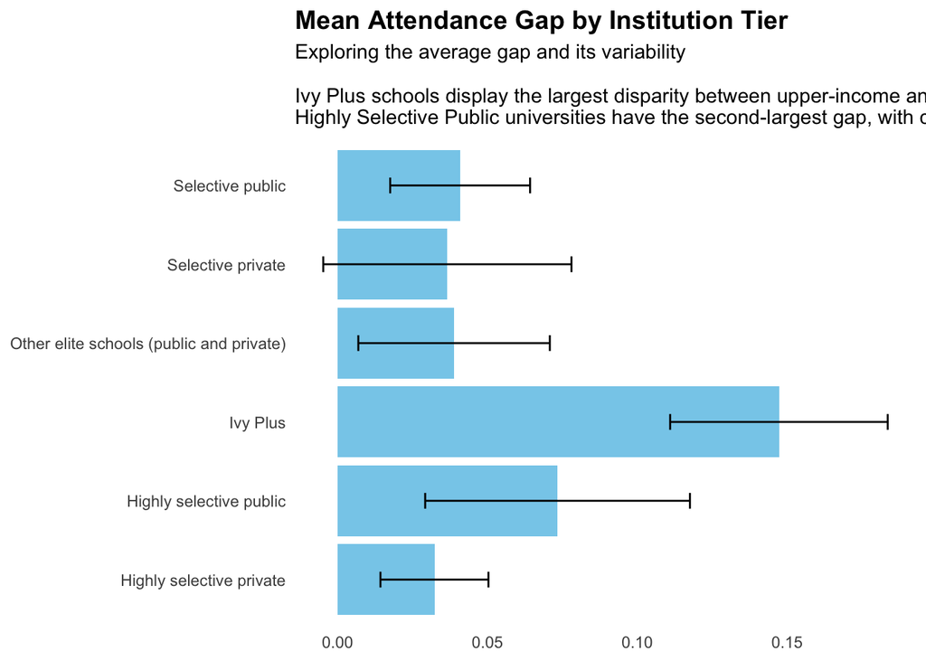

```r
# Box plot of gap by tier
# ggplot(merged_ca, aes(x = tier, y = gap)) +
#   geom_boxplot() +
#   labs(x = "Selectivity Tier", y = "Attendance Gap") +
#   coord_flip()

# Scatter plot of lower vs. upper income attendance by tier
# ggplot(merged_ca, aes(x = lower_income_attendance, y = upper_income_attendance, color = tier)) +
#   geom_point() +
#   labs(x = "Lower Income Attendance", y = "Upper Income Attendance", color = "Selectivity Tier")


# Create the bar plot mean attendance gap by tier
ggplot(tier_summary, aes(x = tier, y = mean_gap)) +
  geom_bar(stat = "identity", fill = "skyblue") +
  geom_errorbar(aes(ymin = mean_gap - sd_gap, ymax = mean_gap + sd_gap), width = 0.2) + # Add error bars showing variability
  labs(title = "Mean Attendance Gap by Institution Tier",
       subtitle = "Exploring the average gap and its variability\n\nIvy Plus schools display the largest disparity between upper-income and lower-income students.\nHighly Selective Public universities have the second-largest gap, with considerable variation in equity.",

       x = NULL,
       y = "Mean Gap") +
  theme_minimal() +
  theme(axis.title.x = element_blank(),
        plot.title = element_text(size = 14, face = "bold"),
        panel.grid.major = element_blank(),
        panel.grid.minor = element_blank()) +
  coord_flip()
```

```r
# Selective Public Institutions show relatively small gaps with some variability in equity.

# Selective Private show relatively small gaps, with some schools showing very equitable attendance rates. In contrast, others have much larger gaps based on the error bar.

# Other Elite Schools (Public and Private): These schools display moderate gaps with higher variability in income-based attendance equity.

# Ivy Plus Institutions: These institutions display the largest disparity between upper-income and lower-income students.

# Highly Selective Public Institutions: These universities have the second-largest gap, but the high standard deviation displays considerable variation in equity among these schools.

# Highly Selective Private Institutions: These institutions show a more balanced distribution of students from different income backgrounds with lower variability.
```

“Ivy Plus” schools, such as Harvard, Yale, Cornell, Columbia, Princeton, Stanford, University of Chicago, University of Pennsylvania, and MIT, display the largest disparity in attendance between upper- and lower-income students, with a mean gap of 0.147. This gap is significantly larger than that of other institution types, and the maximum gap of 0.228 further highlights the unequal access to these prestigious schools. Even the most equitable “Ivy Plus” schools show a minimum gap of 0.0945, indicating that income disparity remains an issue even at the best-performing schools in this category.

“Highly selective public” universities like the University of California, Berkeley, the University of Michigan, and the University of Texas at Austin exhibit the second-largest gap in attendance rates between income groups, with a mean gap of 0.0734. Although this disparity is smaller than that seen at “Ivy Plus” institutions, the relatively high standard deviation of 0.0442 points to significant variation in equity among these schools, with some being much more accessible to lower-income students than others.

In contrast, “highly selective private” institutions like Gonzaga, Syracuse, Baylor, and TCU show a much smaller mean gap of 0.0323, suggesting a more balanced distribution of students from different income backgrounds. The low variability within this category, with a standard deviation of just 0.0180, further indicates that these schools tend to be more consistent in their access.

“Selective private” (BYU, Howard, and Loyola Marymount) and “selective public” schools (Auburn, Florida State, and Alabama), with mean gaps of 0.0366 and 0.0409, respectively, reveal only slightly higher disparities than “highly selective private” schools. These institutions exhibit relatively small gaps, and their low minimum gaps suggest that some schools in these categories are very equitable in attendance for lower-income students.

“Other elite schools” like Notre Dame, Washington University, and Northwestern University display a moderate mean gap of 0.0389, higher than “highly selective private schools” but still relatively small. However, the higher standard deviation of 0.0319 indicates greater variability in income-based attendance equity within this category.

Overall, lower-income students remain vastly underrepresented across all types of institutions. For instance, “Ivy Plus” schools have an average lower-income attendance rate of only 0.0252, while “highly selective public” institutions show an even lower rate of 0.0124. Conversely, upper-income students are overrepresented, with mean attendance rates of 0.172 at “Ivy Plus” schools and 0.0858 at “highly selective public” schools.

#### Plot 3 Application vs. Attendance Rates

```r
# Define lower-income and upper-income groups
lower_income_bins <- c(0, 10, 20, 30)
upper_income_bins <- c(80, 90, 95, 96, 97, 98, 99, 99.9, 100)

# rel_apply: How many students with similar test scores apply to a college compared to other colleges.
# rel_attend: How many students with similar test scores attend a college compared to other colleges.
# rel_apply_instate: How many in-state students apply to a public college compared to other public colleges.
# rel_attend_instate: How many in-state students attend a public college compared to other public colleges.
# rel_apply_oostate: How many out-of-state students apply to a public college compared to other public colleges.
# rel_attend_oostate: How many out-of-state students attend a public college compared to other public colleges.

# Calculate mean application and attendance rates for lower-income students
lower_income_analysis <- merged_ca %>%
  filter(par_income_bin <= 30) %>% # Filter data for lower-incom
  summarize(
    mean_rel_apply = mean(rel_apply, na.rm = TRUE),
    mean_rel_attend = mean(rel_attend, na.rm = TRUE),
    mean_rel_apply_instate = mean(rel_apply_instate, na.rm = TRUE),
    mean_rel_attend_instate = mean(rel_attend_instate, na.rm = TRUE),
    mean_rel_apply_oostate = mean(rel_apply_oostate, na.rm = TRUE),
    mean_rel_attend_oostate = mean(rel_attend_oostate, na.rm = TRUE)
  )

# Calculate mean application and attendance rates for upper-income students
upper_income_analysis <- merged_ca %>%
  filter(par_income_bin >= 80) %>% # Filter data for upper-income
  summarize(
    mean_rel_apply = mean(rel_apply, na.rm = TRUE),
    mean_rel_attend = mean(rel_attend, na.rm = TRUE),
    mean_rel_apply_instate = mean(rel_apply_instate, na.rm = TRUE),
    mean_rel_attend_instate = mean(rel_attend_instate, na.rm = TRUE),
    mean_rel_apply_oostate = mean(rel_apply_oostate, na.rm = TRUE),
    mean_rel_attend_oostate = mean(rel_attend_oostate, na.rm = TRUE)
  )

# Combine the results
comparison <- bind_rows(
  lower_income_analysis %>% mutate(income_group = "Lower-Income"),
  upper_income_analysis %>% mutate(income_group = "Upper-Income")
) %>%
  select(income_group, everything()) # Reorganize columns
comparison
```

| income_group | mean_rel_apply | mean_rel_attend | mean_rel_apply_instate | mean_rel_attend_instate | mean_rel_apply_oostate | mean_rel_attend_oostate |
| --- | --- | --- | --- | --- | --- | --- |
| Lower-Income | 0.8935817 | 0.8171062 | 0.9435895 | 0.9314746 | 0.695466 | 0.618861 |
| Upper-Income | 1.3498875 | 1.5278338 | 1.0587926 | 1.0938719 | 1.521439 | 1.753978 |

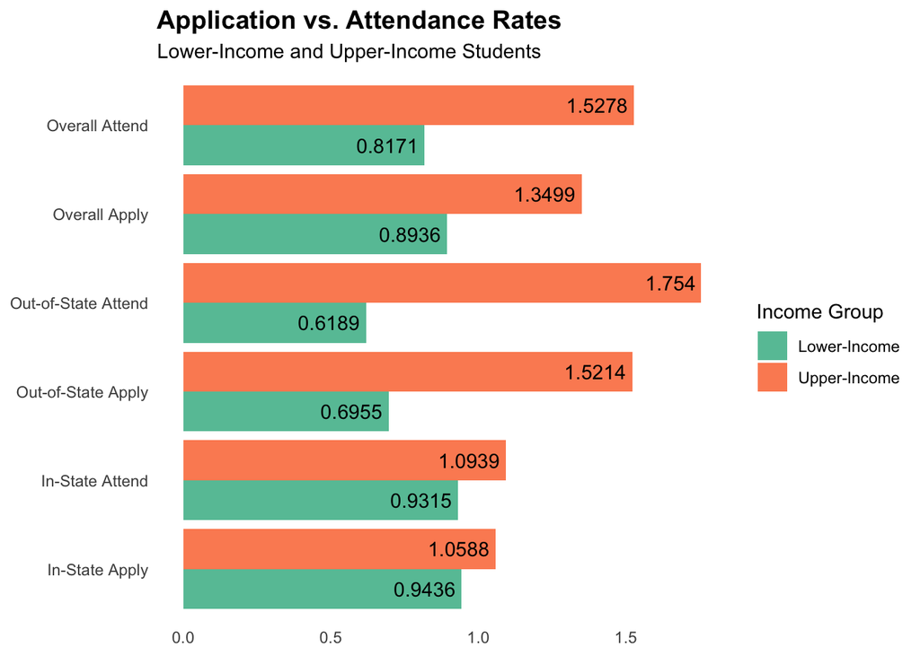

```r
# Create a DataFrame with the summary data
data <- data.frame(
  Income_Group = rep(c("Lower-Income", "Upper-Income"), each = 6),
  Category = rep(c("Overall Apply", "Overall Attend", "In-State Apply", "In-State Attend", "Out-of-State Apply", "Out-of-State Attend"), 2),
  Rate = c(0.8936, 0.8171, 0.9436, 0.9315, 0.6955, 0.6189,
           1.3499, 1.5278, 1.0588, 1.0939, 1.5214, 1.7540))

# Plot the data
ggplot(data, aes(x = Category, y = Rate, fill = Income_Group)) +
  geom_bar(stat = "identity", position = "dodge") +
    geom_text(aes(label = round(Rate, 4)), position = position_dodge(width = 0.9),
      vjust = 0.5, hjust = 1.1) +
  scale_fill_manual(values = brewer.pal(10, "Set2")) +
  labs(title = "Application vs. Attendance Rates",
       subtitle = "Lower-Income and Upper-Income Students",
       x = NULL,
       fill = "Income Group") +
  theme_minimal() +
  theme(axis.title.x = element_blank(),  # Remove x-axis text
        #axis.text.y = element_blank(), # Remove y-axis text
        plot.title = element_text(size = 14, face = "bold"),
        panel.grid.major = element_blank(),
        panel.grid.minor = element_blank()) +
  coord_flip()
```

```r
# The comparison
# Overall Mean Application Rate: 0.8936
# Overall Mean Application Rate: 1.3499

# Overall Mean Attendance Rate: 0.8171
# Overall Mean Attendance Rate: 1.5278

# In-State Mean Application Rate: 0.9436
# In-State Mean Application Rate: 1.0588

# In-State Mean Attendance Rate: 0.9315
# In-State Mean Attendance Rate: 1.0939

# Out-of-State Mean Application Rate: 0.6955
# Out-of-State Mean Application Rate: 1.5214

# Out-of-State Mean Attendance Rate: 0.6189
# Out-of-State Mean Attendance Rate: 1.7540
```

The overall mean application rate for lower-income students is 0.8936, while their mean attendance rate is 0.8171. This indicates a noticeable drop-off between application and attendance, particularly evident for out-of-state institutions. Specifically, the application rate for out-of-state colleges is 0.6955, which is higher than the attendance rate of 0.6189. This suggests that lower-income students face significant challenges in following through with attendance, possibly due to financial constraints or logistical difficulties. In contrast, the application rate for in-state colleges is slightly higher at 0.9436, with an attendance rate of 0.9315. While most in-state applicants attend, there is still a small gap between application and attendance, highlighting that barriers remain for lower-income students even with better access.

The overall mean application rate for upper-income students is 1.3499, and their mean attendance rate is even higher at 1.5278. This substantial difference shows that upper-income students are more likely to both apply and attend the colleges they apply to. The data reveals a strong follow-through on applications, with higher attendance rates than application rates. When focusing on in-state colleges, the application rate is 1.0588, which is lower than the attendance rate of 1.0939, indicating a high likelihood of attending once they apply. For out-of-state colleges, the application rate is 1.5214, with an attendance rate of 1.7540. Compared to the application rate, this substantial attendance rate suggests that upper-income students who apply to out-of-state colleges are very likely to attend. This indicates a strong follow-through and fewer barriers for upper-income students, reflecting their greater resources and access to educational opportunities.